# Evolutionary Quantitative Genetics Workshop

Jen Reeve

6/10/2019

```r
library(tidyverse)
library(MCMCglmm)
library(MasterBayes)
library(plyr)
library(rgl)
library(MASS)
library(car)
library(akima)
library(OUwie)
library(corHMM)
library(phytools)
library(geiger)
library(ape)
library(nlme)
library(bayou)
```

# Monday June 10 2019

## Lecture 1.1: Introductions

FHL is a land and marine preserve, part of UW.

Low tides Friday/Saturday morning

27 total students, 10ish instructors

### Steve Arnold

We are going to start at a micro level, but then we will expand out so we can integrate and look at deep evolutionary time.

Steve’s lectures will have PDF presentation, the PPT presentation (with notes), lecture notes (essentially the chapters of a book he is writing) and readings relevant to the lecture.

### Joe Felsenstein: the history of quantitative genetics and the basic model to keep in mind

Late 1800s Galton and Pearson both tried to do quantitative theories of quant./discrete characters (prior to rediscovery of Mendel’s work). They were crucial for development of statistical methods. They were also the founders of the eugenetics movements…. so there’s that.

Standard quantitative genetic model: apply the effects of all relevant genes and then apply the environmental effect

## Lecture 1.2: Molecular quantitative genetics (Patrick Phillips)

Early split between molecular and quantitative genetics, fundamental distinction is what the fundamental genetic unit is. Molecular genetics uses the locus as the smallest unit. Quantitative genetics considers the allele to be the fundamental unit. This allows for considering the different effects of different alleles, including how strong the effects are.

Examples: - Pleiotropy: - mol-bio: property of locus, is or is not - quant-gen: property of allele, can be variable btw and within loci and can evolve. - Epistasis: - mol-bio: mutation at one locus blocks effects of mutation at another - quant-gen: many possible types of interaction

Multivariate selection: $\Delta\bar{z}=G\beta$

Evolution of genetic architecture: - Pleiotropy: alleles affect multiple traits (Edinborough School) - Linkage: alleles/genes tend to be inherited together (Birmingham School)

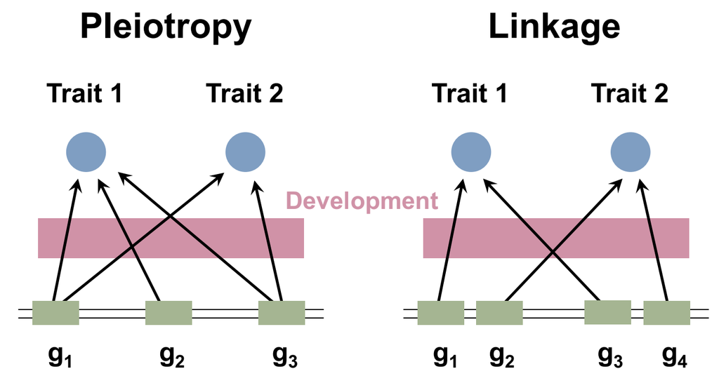

Pleiotropy vs Linkage

These matter b/c if you select for one trait, you can pull a second trait along with it.

Evolution of the G matrix:

Finding the allele that matters

## Lecture 1.3: Inheritance of a single trait and response to selection (Steve Arnold)

Probably massively redundant, but that’s good b/c it’s a fire hose.

Most traits are influenced by many genes, and we can model these traits with a statistical approach. This is not a new concept, Fischer was thinking about this in 1918. Additive genetic variance is the statistical concept that allows us to model inheritance and response to selection.

### Phenotypic resemblance

Looking at offspring as a function of parents.

### Model

$z$ is the phenotype, $x$ is the additive genetic effect and $e$ is the environmental effect.

Phenotypic value: $z = x + e$

Phenotypic mean: $\bar{z} = \bar{x} + \bar{e}$

Phenotypic variance: $ P = G + E$

$G$ is the additive genetic variance which is the key statistical property responsible for Galton’s regression

To move beyond parents and offspring we need to include dominance ($d$) and epistasis ($i$) in addition to the additive effects ($x$)

### Examples

Mother-daughter relationship in vertebral counts in garter snakes

### Why don’t we run out of additive genetic variance?

Why don’t we just lose genetic variance if under a stabilizing pressure? Mutation!

### Changing the trait mean with selection

- Response to selection as a regression problem
- response to selection in a finite population
- response to long term selection

### Conclusions

- G is the key to understanding resemblance
- G is the key to modeling response to selection
- G is nibbled away by selection and restored by mutation

## Exercise 1.1: Estimation of heritability by parent-offspring regression in R

**Part 1 Get the data file** #Modify the setwd line below so that it points to the folder you choose #Make sure the data txt file is in that folder

```r
file_path <- "data/R_inland_snake_data.txt"
thamnophis = read.table(file_path,header=TRUE)
attach(thamnophis)
head(thamnophis)
```

```
##   ï..local family body tail mid ilab slab post
## 1   INLAND    420  165   75  21   20   16    4
## 2   INLAND    420  162   82  21   NA   NA    6
## 3   INLAND    420  162   82  21   20   16    6
## 4   INLAND    420  163   77  21   19   16    6
## 5   INLAND    420  164   79  21   20   16    6
## 6   INLAND    420  164   80  21   20   16    6
```

**Part 2 Create a list of family names, no repeats**

```r
family.list=unique(family)
family.list
```

```
##   [1]  420  437  438  440  494  497  507  511  512  515  516  522  534  540
##  [15]  541  543  545  549  550  554  556  591  676  686  687  693  697  698
##  [29]  703  704  711  712  713  720  724  729  737  895  896  905  911  916
##  [43]  918  920  924  929  934  939  940  947  976  986  987  998 1004 1005
##  [57] 1008 1011 1044 1045 1046 1047 1048 1052 1056 1058 1060 1169 1180 1185
##  [71] 1186 1200 1212 1227  160  249  259  260  265  267  268  274  277  278
##  [85]  279  283  352  355  358  369  370  371  374  375  376  377  379  385
##  [99]  386  452  470  474  482  485  486  904  906  908  917  921  922  923
## [113]  926  927  930  931  933  935  936  937  938  941  942  943  944  946
## [127]  948  949  950  951  954  981  999 1006 1010 1016 1018 1019 1022 1024
## [141] 1027 1054 1073 1080 1088 1090 1102 1144 1162 1166 1167 1178 1181 1182
## [155] 1195 1198 1199 1209 1210 1214 1215
```

```r
#The length of family.list is
length(family.list)
```

```
## [1] 161
```

**Part 3 Use family.list to calculate h2 and plot**

```r
moms=NULL
kids=NULL
for (i in family.list){
  byfam=subset(body,family==i)
  #Create a vector of body vertebrae counts for family i
  moms=rbind(moms,byfam[1])
  #Save the moms count as the next element in the vector "moms"
  kids=rbind(kids,mean(byfam[-1], na.rm=TRUE))
  #Save the mean of the kids count as the next element in the vector "kids" (you are excluding the 1st element of the vector, which is the mom)
}

#Linear regression of kids on moms, will save a bunch of stuff in ls; to see the summary statistics run "summary(ls)", we especially want the slope, which is stored in ls$coefficients
ls=lsfit(moms,kids)
```

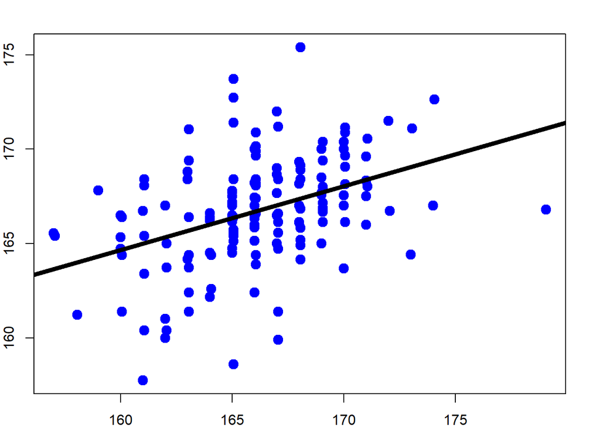

```r
par(mar = rep(2, 4))
plot(moms, kids, col='blue', pch=19, cex=1.5)

#Extract the 2nd coefficient from the object "coefficients" in "ls"
slope=ls$coefficients[2]
abline(ls, lwd=5)
```

```r
#the heritability estimate is twice the slope because we are using just one parent, not both
h.squared=2*slope
h.squared
```

```
##         X
## 0.6781192
```

**Part 4 Make a function called h2 that will estimate heritability**

```r
h2=function(V){
  family.list=unique(family)
  moms=NULL
  kids=NULL
  for (i in family.list){
    byfam=subset(V, family==i)
    moms=rbind(moms, byfam[1])
    kids=rbind(kids, mean(byfam[-1], na.rm=TRUE))
  }
  plot(moms, kids, col='blue', pch=19, cex=1.5)
  ls=lsfit(moms, kids)
  abline(ls, lwd=5)

  slope=ls$coeff[2]
  h.squared=2*slope

  print('Point estimate of heritability is')
  h.squared
}
print('Point estimate of heritability is')
```

```
## [1] "Point estimate of heritability is"
```

```r
h.squared
```

```
##         X
## 0.6781192
```

**Test out the function on 3 traits by making point estimates of heritability**

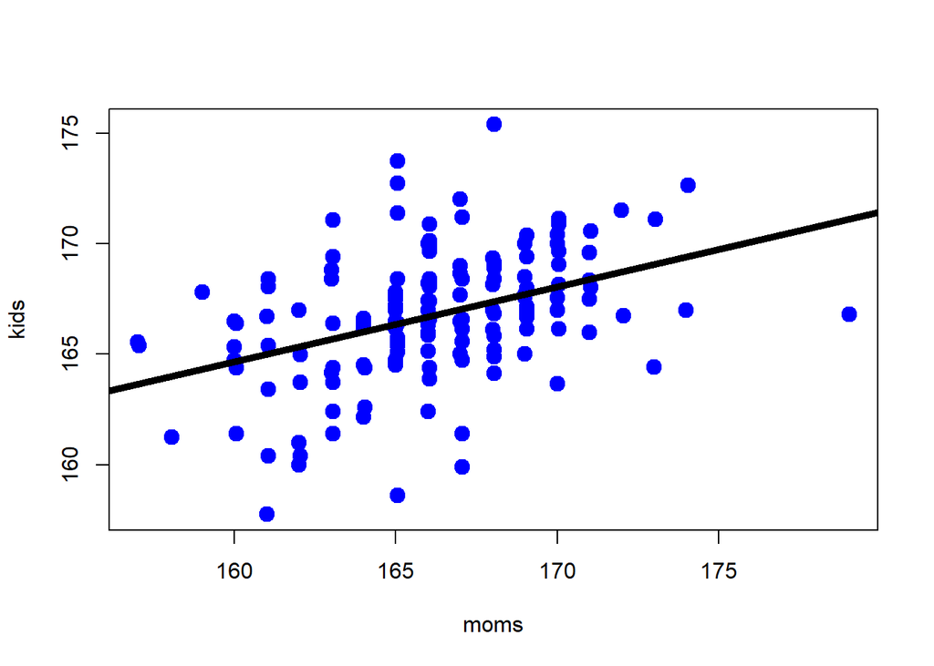

```
## [1] "Point estimate of heritability is"
```

```
##         X
## 0.6781192
```

```r
h2(body)
```

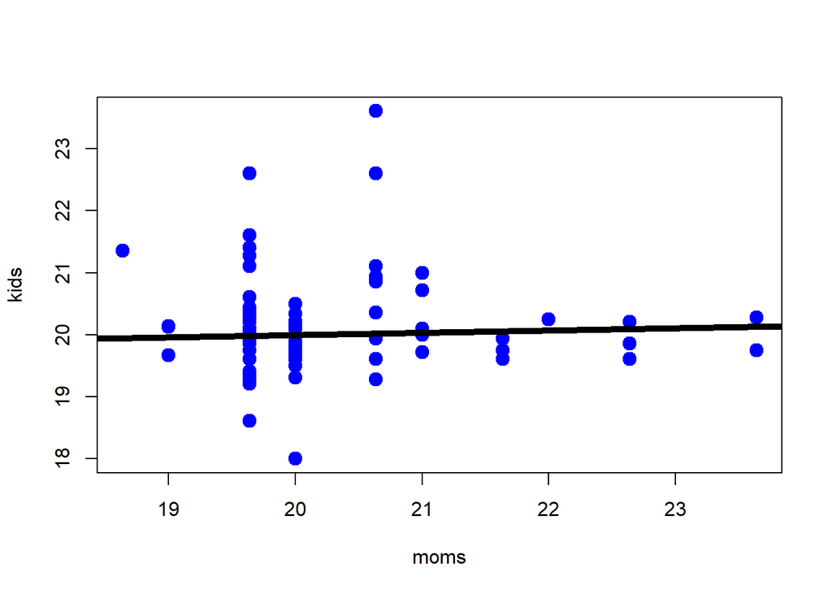

```
## [1] "Point estimate of heritability is"
```

```
##          X
## 0.07257756
```

```r
h2(ilab)
```

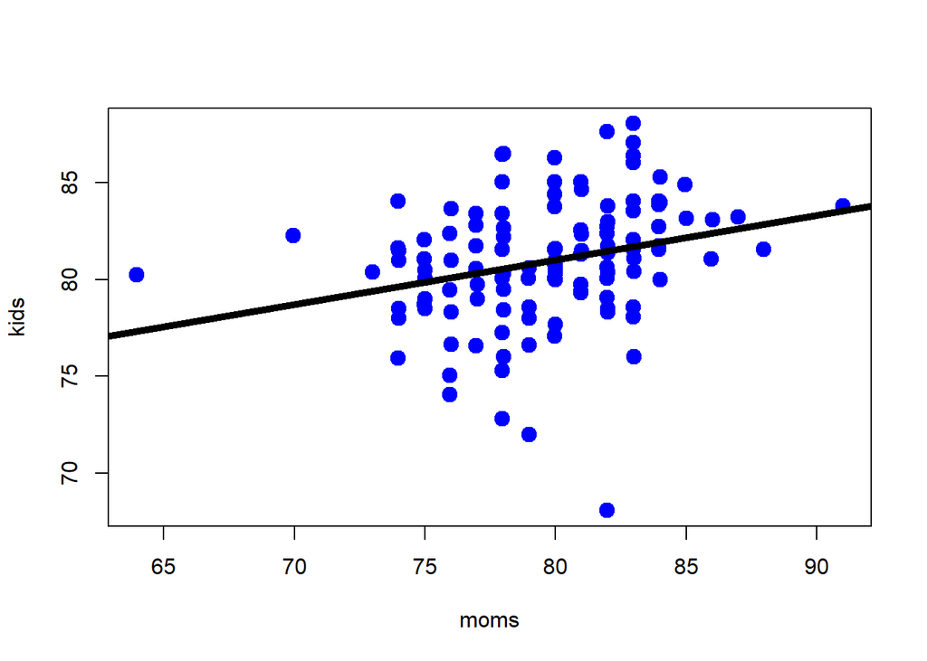

```
## [1] "Point estimate of heritability is"
```

```
##         X
## 0.4611018
```

```r
h2(tail)
```

# Now plot a histogram of the bootstrap heritability estimates

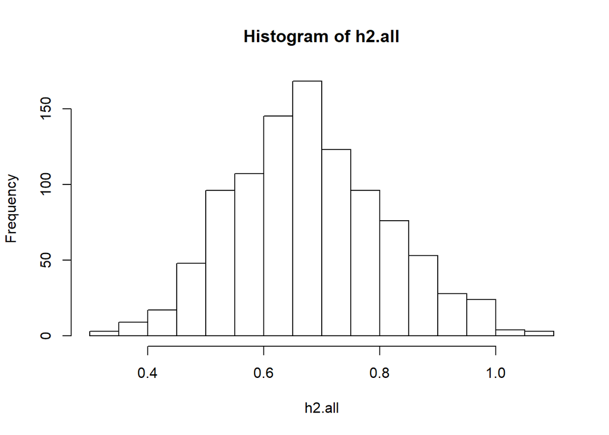

```r
hist(h2.all)
```

```r
#What does this histogram tell us?
```

## Lecture 1.4: Multivariate inheritance and response to selection (Steve Arnold)

We can expand the G statistic into a G matrix to observe multiple traits simultaneously.

Traits can run together in families.

So what’s the model for multivariate resemblance?

Phenotypic value: $z = x + e = \begin{bmatrix} z_1\\ z_2\end{bmatrix} = \begin{bmatrix} x_1\\ x_2\end{bmatrix} + \begin{bmatrix} e_1\\ e_2\end{bmatrix}$

Phenotypic mean: $\bar{z} = \bar{x} + \bar{e} = \begin{bmatrix} \bar{z_1}\\ \bar{z_2}\end{bmatrix} = \begin{bmatrix} \bar{x_1}\\ \bar{x_2}\end{bmatrix} + \begin{bmatrix} \bar{e_1}\\ \bar{e_2}\end{bmatrix}$

Phenotypic variance/covariance: $P = G + E = \begin{bmatrix} P_{11} & P_{12}\\P_{12} & P_{22}\end{bmatrix} = \begin{bmatrix} G_{11} & G_{12}\\G_{12} & G_{22}\end{bmatrix} + \begin{bmatrix} E_{11} & E_{12}\\E_{12} & E_{22}\end{bmatrix}$

The G matrix describes the cloud of genetic values. We can consider this via principal components (or eigenvectors). The first principal component has the most genetic variance. The second principal component is orthogonal to the first.

The genetic correlation is $r_g = G_{12}/\sqrt{G_{11}}G_{22}$

## Exercise 1.2: multivariate inheritance

### Tutorial 1: Matrix algebra session

You will need to install some packages (MASS, car, rgl) if you have not already done so. Find the Packages tab in the bottom right and use the dialog box

Start with the addition of two vectors. The first and third statements define the two vectors

Notice that R treats vectors as 1 column or 1 row matrices

```r
a=matrix(data=c(2,3),nrow=2,ncol=1)
a
```

```
##      [,1]
## [1,]    2
## [2,]    3
```

```r
e=matrix(data=c(3,4),nrow=2,ncol=1)
e
```

```
##      [,1]
## [1,]    3
## [2,]    4
```

Now add the two vectors

```r
z=a+e
z
```

```
##      [,1]
## [1,]    5
## [2,]    7
```

Now try matrix addition. We begin by defining the two matrices that we will add.

```r
G=matrix(data=c(2,3,3,8),nrow=2,ncol=2)
G
```

```
##      [,1] [,2]
## [1,]    2    3
## [2,]    3    8
```

```r
E=matrix(data=c(1,2,2,5),nrow=2,ncol=2)
E
```

```
##      [,1] [,2]
## [1,]    1    2
## [2,]    2    5
```

Add the two matrices, we get

```r
P=G+E
P
```

```
##      [,1] [,2]
## [1,]    3    5
## [2,]    5   13
```

Next, multiply a matrix by a vector. The following exercise computes the response to directional selection on two traits, given the G-matrix and a vector of selection gradients.

```r
beta=matrix(data=c(0.2,0.4),nrow=2,ncol=1)
beta
```

```
##      [,1]
## [1,]  0.2
## [2,]  0.4
```

The response to selection is

```r
deltazbar=G %*% beta
deltazbar
```

```
##      [,1]
## [1,]  1.6
## [2,]  3.8
```

Now, the multiplication of two matrices. Here we depart from the sequence in the Arnold 1994 Appendix. We will compute the inverse of a matrix and see if the product of a matrix and its inverse yields the identity matrix.

```r
Ginverse=solve(G)
Ginverse
```

```
##            [,1]       [,2]
## [1,]  1.1428571 -0.4285714
## [2,] -0.4285714  0.2857143
```

```r
G %*% Ginverse
```

```
##      [,1]          [,2]
## [1,]    1 -1.110223e-16
## [2,]    0  1.000000e+00
```

Finally, solve for the eigenvalues and eigenvectors of the G-matrix.

What does the output mean?

```r
eigen(G)
```

```
## eigen() decomposition
## $values
## [1] 9.2426407 0.7573593
##
## $vectors
##           [,1]       [,2]
## [1,] 0.3826834 -0.9238795
## [2,] 0.9238795  0.3826834
```

To find out what the output means, write some script that will take a sample using a bivariate G matrix, then plot the 95% confidence ellipse for that sample and the eigenvectors of our G matrix

First, we define our matrix and take a look at it

```r
G=matrix(data=c(1,0.8,0.8,1),nrow=2, ncol=2,byrow=TRUE)
G
```

```
##      [,1] [,2]
## [1,]  1.0  0.8
## [2,]  0.8  1.0
```

Second, we load two libraries that we will need to call

```r
#library(MASS)
#library(car)
```

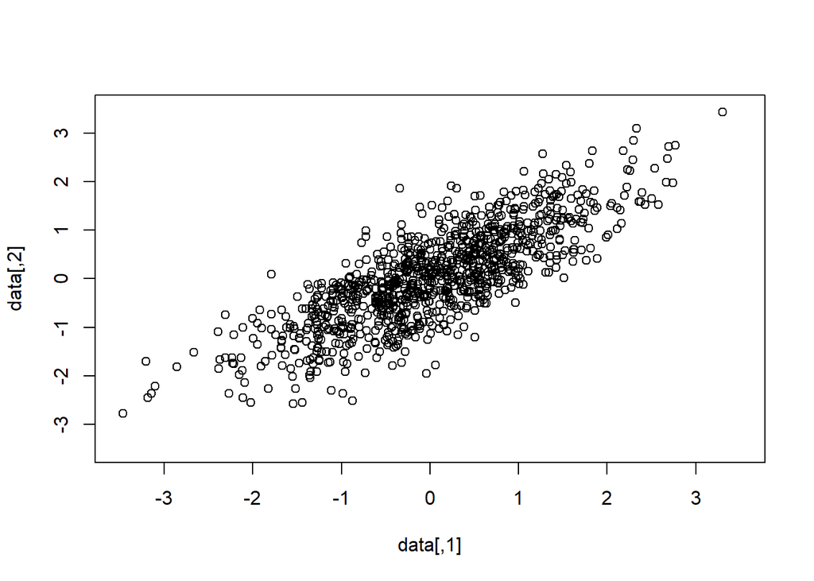

```r
data <- mvrnorm(1000, mu = c(0,0), Sigma=G)

#Fourth, we plot our data
x.range = c(-3.5,3.5)
y.range = c(-3.5,3.5)

plot(data, xlim=x.range, ylim=y.range)
```

Fifth, we plot the 95% confidence ellipse in green

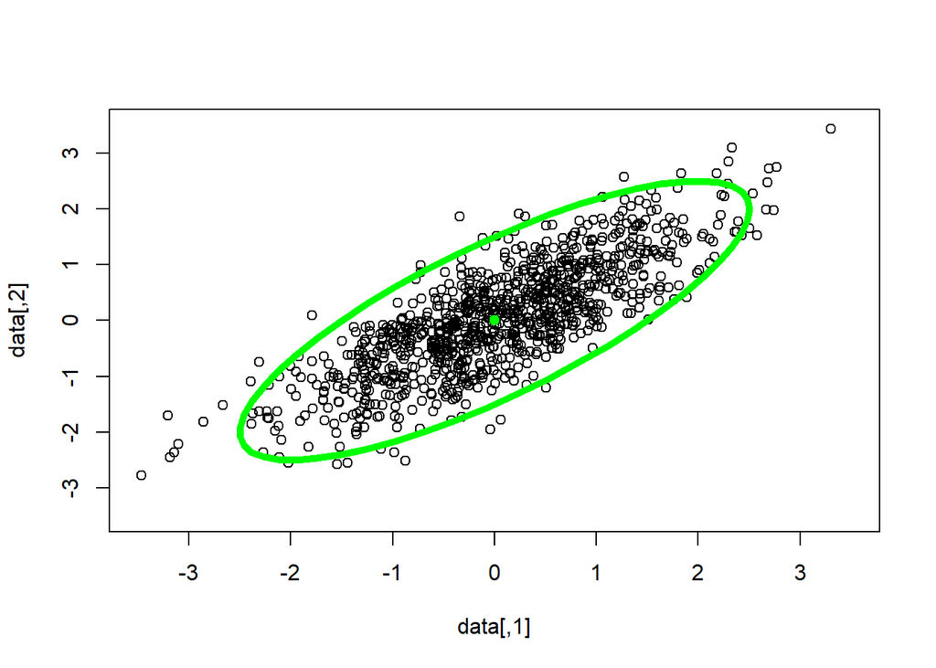

```r
plot(data, xlim=x.range, ylim=y.range)
null.bar=c(0,0)
ellipse(center=null.bar, shape=G, radius=2.5, center.cex=1, lwd=5, col="green", add=TRUE)
```

Sixth, take a look at the eigenvectors of our G matrix, so we understand the script that follows

```r
eigen(G)$vectors
```

```
##           [,1]       [,2]
## [1,] 0.7071068 -0.7071068
## [2,] 0.7071068  0.7071068
```

Note that the center of the plot is null.bar, the bivariate mean

```r
null.bar
```

```
## [1] 0 0
```

Seventh, plot the first eigenvector in blue. We want to use the lines function, so we need to specify three points to connect

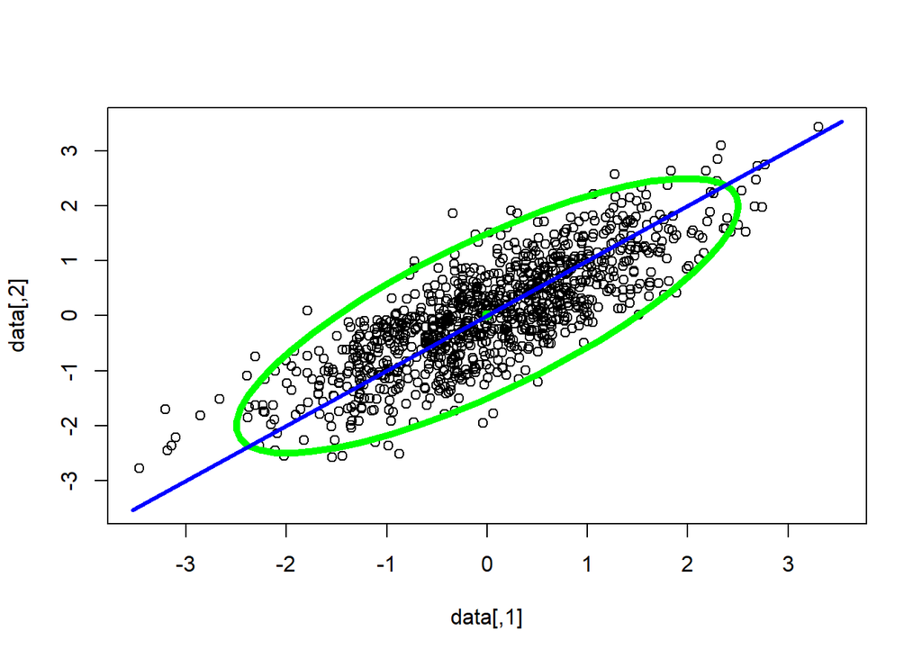

```r
plot(data, xlim=x.range, ylim=y.range)
ellipse(center=null.bar, shape=G, radius=2.5, center.cex=1, lwd=5, col="green", add=TRUE)
n=5
delx1 = null.bar[1]  + n*eigen(G)$vectors[1,1]
delx2 = null.bar[2]  + n*eigen(G)$vectors[2,1]
delx11 = null.bar[1]  - n*eigen(G)$vectors[1,1]
delx22 = null.bar[2]  - n*eigen(G)$vectors[2,1]
x.values=c(null.bar[1] , delx1, delx11)
y.values=c(null.bar[2] , delx2, delx22)
lines(x.values, y.values, lwd=3, col="blue")
```

Finally, plot the second eigenvector in red. Also, need to make this a square plot so that our axes look orthogonal

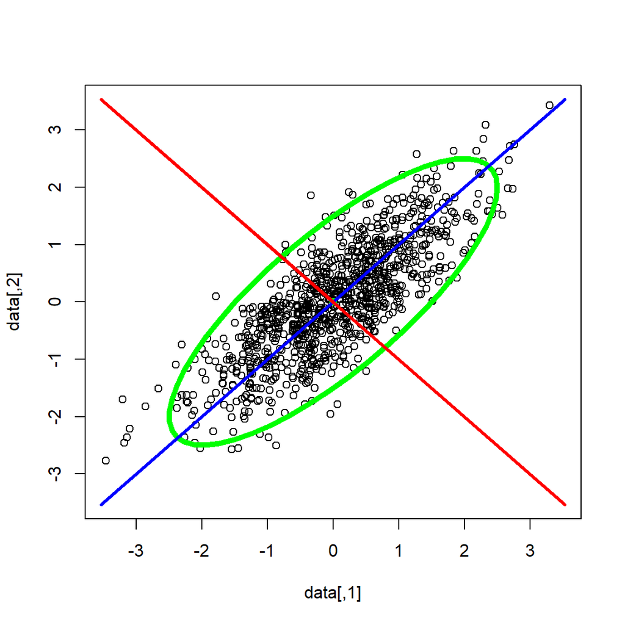

```r
plot(data, xlim=x.range, ylim=y.range)
ellipse(center=null.bar, shape=G, radius=2.5, center.cex=1, lwd=5, col="green", add=TRUE)
n=5
delx1 = null.bar[1]  + n*eigen(G)$vectors[1,1]
delx2 = null.bar[2]  + n*eigen(G)$vectors[2,1]
delx11 = null.bar[1]  - n*eigen(G)$vectors[1,1]
delx22 = null.bar[2]  - n*eigen(G)$vectors[2,1]
x.values=c(null.bar[1] , delx1, delx11)
y.values=c(null.bar[2] , delx2, delx22)
lines(x.values, y.values, lwd=3, col="blue")
m=5
delx1 = null.bar[1] + m*eigen(G)$vectors[1,2]
delx2 = null.bar[2] + m*eigen(G)$vectors[2,2]
delx11 =  null.bar[1] - m*eigen(G)$vectors[1,2]
delx22 =  null.bar[2]  - m*eigen(G)$vectors[2,2]
x.values=c(null.bar[1], delx1, delx11)
y.values=c(null.bar[2] , delx2, delx22)
lines(x.values, y.values, lwd=3, col="red")
```

Now try changing the G matrix and see how the eigenvectors are affected. You will need to change the G statement and re-run data

Finally, try plotting a 3 dimensional G-matrix. But first you need to find and load package rgl

```r
#library(rgl)

G=matrix(data=c(1,0.9,0.8,0.9,1,0.8,0.8,0.8,1),nrow=3, ncol=3,byrow=TRUE)
G
```

```
##      [,1] [,2] [,3]
## [1,]  1.0  0.9  0.8
## [2,]  0.9  1.0  0.8
## [3,]  0.8  0.8  1.0
```

```r
data <- mvrnorm(1000, mu = c(0,0,0), Sigma=G)
plot3d(data)
```

Now try modifying the input G-matrix in the chuck above and re-run it

### Tutorial 2: Tutorial on direct and indirect selection

Open R Studio and begin the session by specifying a P-matrix

```r
P=matrix(data=c(1,0,0,1), nrow=2, ncol=2)
P
```

```
##      [,1] [,2]
## [1,]    1    0
## [2,]    0    1
```

We can make the specification a little less tedious by writing a function

```r
M=function(a, b, c) {matrix(data=c(a,b,b,c),nrow=2,ncol=2)}
#so that when we call it, we do a little less typing
P=M(1,0,1)
P
```

```
##      [,1] [,2]
## [1,]    1    0
## [2,]    0    1
```

Now, let beta specify a beta vector corresponding to direct selection on both traits of equal magnitude

```r
beta=c(1,1)
beta
```

```
## [1] 1 1
```

If that selection acts on our P-matrix, the resulting shifts in the means are given by the s-vector

For this step we are using equation (2.03) from our lecture notes

```r
s=P%*%beta
s
```

```
##      [,1]
## [1,]    1
## [2,]    1
```

If the two traits are highly correlated, we solve for the s-vector with the following steps

```r
P=M(1,0.9,1)
P
```

```
##      [,1] [,2]
## [1,]  1.0  0.9
## [2,]  0.9  1.0
```

```r
s=P%*%beta
s
```

```
##      [,1]
## [1,]  1.9
## [2,]  1.9
```

But now if selection acts on just one trait, we get a bit of a surprise when we solve for s

```r
beta=c(1,0)
beta
```

```
## [1] 1 0
```

```r
s=P%*%beta
s
```

```
##      [,1]
## [1,]  1.0
## [2,]  0.9
```

Can you draw graphs that illustrate each of these three selection scenarios?

### Using PCP software (h2boot) to estimate G-matrices

The aim of this exercise is to gain some familiarity with multivariate inheritance. We will gain this familiarity by estimating and comparing genetic variances and covariances for a suite of six traits in two populations of garter snakes. You estimated heritabilities of these traits in one of these populations (inland) in Exercise 1.1

Note: Initially only 10 selections will appear, but as you enter the choices below the menu will expand to 13 choices.

1. Input file name: all_females_2pops.txt
2. Trait names included in file: yes
3. Output file name: All_females_out.txt
4. Number of bootstrap runs: 1000
5. Random number seed: 1994
6. Create files for bootstrap distributions: no
7. Type of analysis: Parent-off regression w/full-sib ANOVA
8. Only use families with complete data: no
9. Analyzing multiple populations: yes
10. Make population comparisons: yes
11. Bend non-positive definite matrices: yes
12. Automatically order eigenvectors in PCP analysis: yes enter 0) End selection and run program.

Now into interpretation:

Interpreting the probability values for various outcomes in the h2boot output for the INLAND population by plotting normal distributions in R. After each highlighted statement, paste the command lines into R.

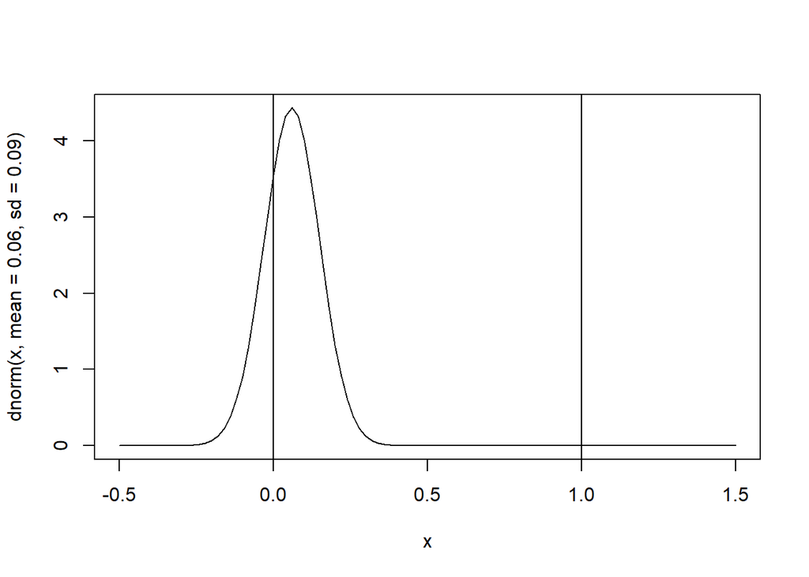

```r
curve(dnorm(x, mean=0.06, sd=0.09), xlim=c(-0.5,1.5))
x.values=c(1,1)
y.values=c(-5,5)
lines(x.values, y.values)
x.values=c(0,0)
y.values=c(-5,5)
lines(x.values, y.values)
```

In other words, we can’t bound the estimate away from 0)

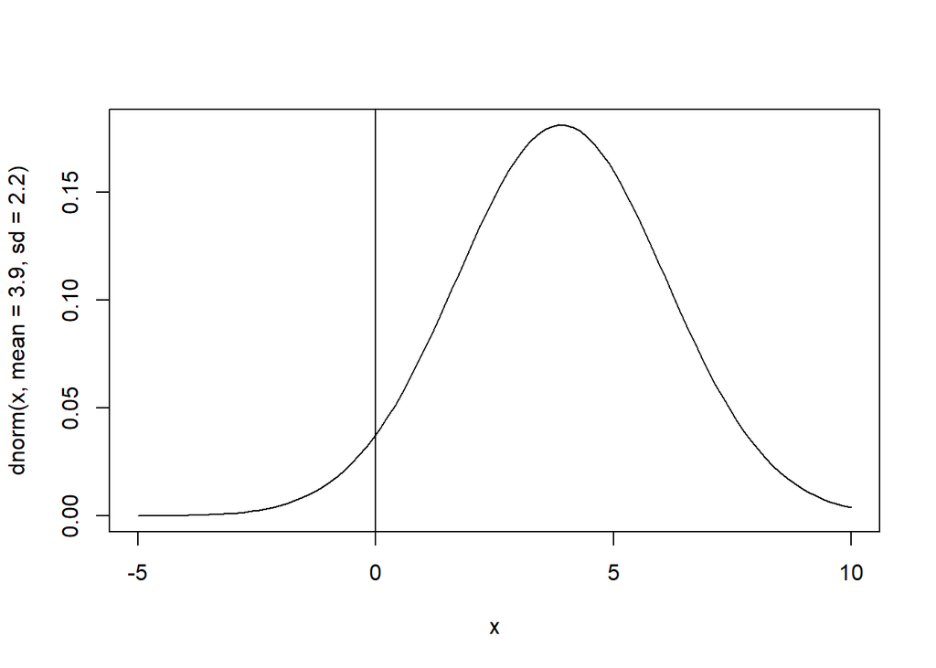

```r
curve(dnorm(x, mean=3.9, sd=2.2), xlim=c(-5,10))
x.values=c(0,0)
y.values=c(-5,5)
lines(x.values, y.values)
```

Here’s an example of a bootstrap distribution in which the parameter lies between -1 and +1. The example is the phenotypic correlations between BODY and SUB, for which the point estimate is about 0.25 with a standard error of about 0.14. The bootstrap distribution shows no probability that the estimate is less than -1 (0.00) or more than +1 (0.00), and a low probability that the estimate is less than 0 (0.074)

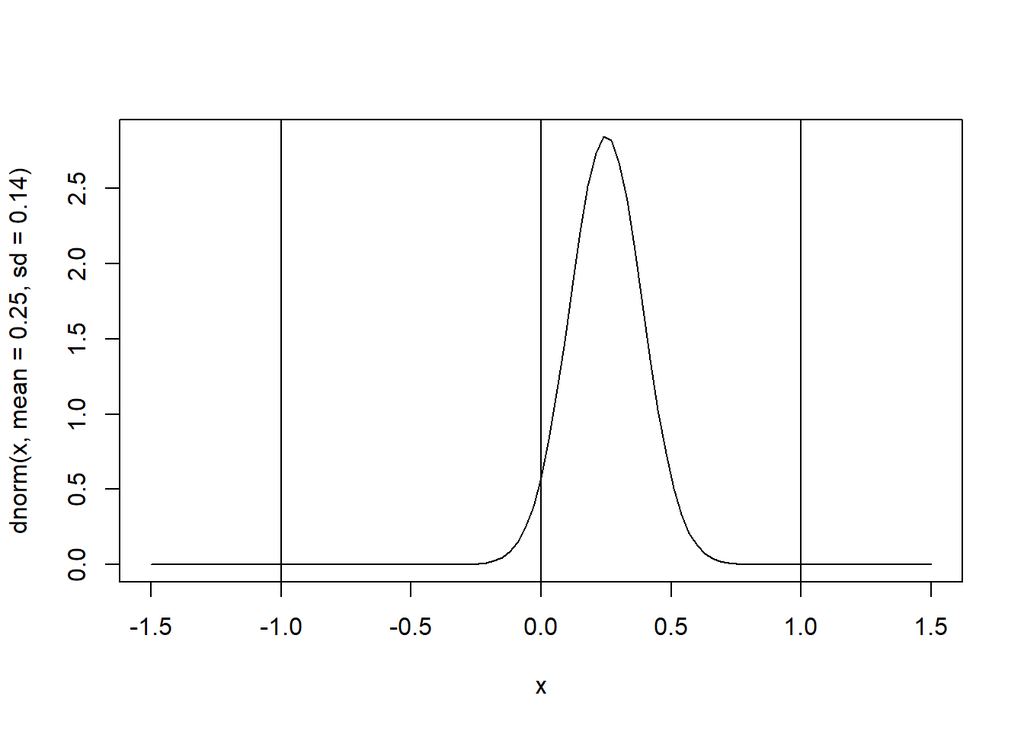

```r
curve(dnorm(x, mean=0.25, sd=0.14), xlim=c(-1.5,1.5))
x.values=c(0,0)
y.values=c(-5,5)
lines(x.values, y.values)
x.values=c(1,1)
y.values=c(-5,5)
lines(x.values, y.values)
x.values=c(-1,-1)
y.values=c(-5,5)
lines(x.values, y.values)
```

Here’s another example of a bootstrap distribution in which the parameter lies between -1 and +1. The example is the phenotypic correlation between BODY and ILAB, for which the point estimate is about 0.06 with a standard error of about 0.34. The bootstrap distribution shows a small probability that the estimate is less than -1 (0.002) or more than +1 (0.006), and a high probability that the estimate lies in the vicinity of 0 (0.852)

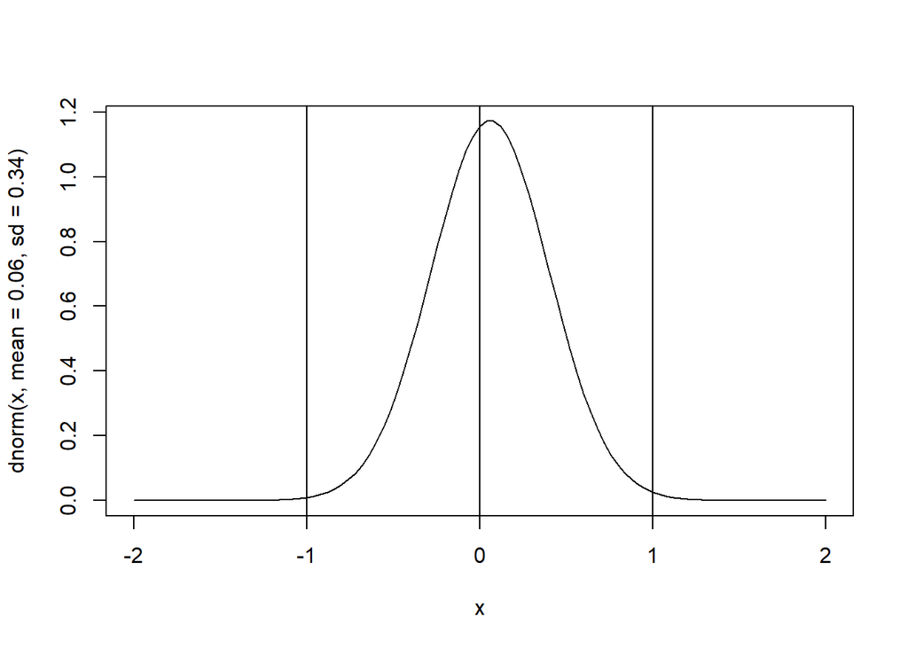

```r
curve(dnorm(x, mean=0.06, sd=0.34), xlim=c(-2,2))
x.values=c(0,0)
y.values=c(-5,5)
lines(x.values, y.values)
x.values=c(1,1)
y.values=c(-5,5)
lines(x.values, y.values)
x.values=c(-1,-1)
y.values=c(-5,5)
lines(x.values, y.values)
```

**Viewing the bootstrap output with histograms**

To see the bootstrap distributions produced by h2boot, you should have answered ‘yes’ to the query ‘Create files for bootstrap distributions?’. If you did not answer ‘yes’, go back thru the instructions in h2boot and answer ‘yes’ to that query. Then, after running h2boot, look for the file named ‘h2dist0.txt’ on your desktop or folder. It contains the bootstrap distribution of heritability estimates for the first population, which is named ‘0’. Open the file in Notepad and add a header line that reads ‘body tail mid ilab slab post’. Rename the file ‘h2dist0_header.txt’ and save it in a desktop folder called ‘R wd’. Now, tell R where to find ‘R wd’ and make it your working directory, by modifying the first command below.

```r
#setwd('C:/Documents and Settings/arnolds/Desktop/R wd')
#Read in the data file you just created and call it 'boot_output'
 boot_output = read.table('h2dist0_header.txt',header=T)
#Attach the data file to your local environment
attach(boot_output)
```

Make histograms of the bootstrap distributions, one trait at a time, each time asking hist to place counts of observations on top of each bar in the histogram

```r
hist(body, labels=T)
hist(tail, labels=T)
hist(mid, labels=T)
hist(ilab, labels=T)
hist(slab, labels=T)
hist(post, labels=T)
```

Compare each of these histograms to the appropriate output column in all_females_2pops.out For which traits can we claim that the point estimate of h2 is bounded away from zero? How can we calculate the significance level for h2 estimate for, say, the body trait?

For that discussion we will use the final section of the h2boot output (which shows estimates of matrices under different models of population similarity), but we also need output from a second program, cpcrand.exe. To get out put from that program go back to the PCP website, download cpcrand.exe and place it in the same folder as the data file All_females_2pops. Run cpcrand.exe (in the same way that you ran h2boot). When the command screen comes up, answer the queries as follows:

```
Input file name: All_females_2pops.txt
Trait names included in file: yes
Output file name: cpc.out
Number of randomization runs: 1000
Random number seed: 1996
Create files for likelihood distributions: yes
Type of analysis: Parent-off regression w/full-sib ANOVA
Only use families with complete data: yes
Bend non-positive definite matrices: yes
Automatically order eigenvectors in PCP analysis: yes
```

This program will conduct statistical tests for various models of similarity between the two G-matrices (identity, proportionality, common principal components, etc). Stand by with your output file (cpc.out) for discussion in class. We will compare the cpc.out results for comparison of G-matrices with Table 3 and Figure 3 in Phillips & Arnold 1999.

# Tuesday June 11 2019

## Lecture 2.1: Estimation of inheritance with fixed and random errors (Patrick Carter)

Dealing with more complex datasets: - linear mixed models

This means that there are both fixed and random effects. - fixed effects: population specific/experimental effects - random effects: variables randomly sampled from a populations (ie: individuals sampled from a pop.)

Another way to think about fixed v random: would you be able to get the effect again if you repeated the experiment? Temp of experiment is fixed, the random individual measured (and thus thing from the distribution) causes random effects. (Courtesy of Patrick Phillips)

### The animal model

So named only for who developed it, not what it works on.

$\color{red}{y}=\color{green}{X\beta}+\color{blue}{Za}+\color{purple}{e}$